# Mapa przyszłości regionów – predykcja depopulacji powiatów peryferyjnych z wykorzystaniem GIS i Machine Learning

Zespół projektowy ID-1362

23.11.2026

## 1. Cel i pytanie badawcze

**Hipoteza:** wzrost peryferyjności powiatu (niski dochód, słaby rynek pracy, starzenie się ludności, słabsza dostępność usług i większa odległość od ośrodków) wiąże się z szybszym odpływem mieszkańców.

Projekt łączy trzy elementy z tytułu:

1. **Predykcja:** prognoza rocznej zmiany ludności powiatów peryferyjnych na lata 2025–2030, z modelu wybranego w porównaniu 13 modeli (elastic net) i z walidacją ex ante na latach, których model nie widział.
2. **GIS:** klasyfikacja przestrzenna 380 powiatów, odległość od miast wojewódzkich, autokorelacja przestrzenna (Moran I, LISA), lokalny model GW-XGBoost oraz mapy prognoz i scenariuszy.
3. **Machine Learning a ekonometria:** XGBoost porównany z panelowym modelem efektów stałych (FE) w identycznym schemacie walidacji.

### Rola poszczególnych modeli

Żaden model nie jest najlepszy do wszystkiego, dlatego każde pytanie badawcze ma przypisany model, który odpowiada na nie najlepiej. Kluczowe wyniki sprawdzamy drugim modelem.

| Pytanie | Model główny | Dlaczego | Kontrola odporności |
| --- | --- | --- | --- |
| Jak zmieni się ludność do 2030 r.? (mapa przyszłości) | elastic net | najniższy średni błąd ex ante 2019–2024; istotnie lepszy od FE (test DM z korektą Holma), niższy błąd także na odłożonych latach 2023–2024 | prognoza XGBoost (sekcja 6) |
| Jakie czynniki i w którą stronę? | panel FE, SDM | interpretowalne współczynniki, istotność, efekty sąsiedztwa | ważność cech w EN i XGBoost (sekcja 4) |
| Czy zależności są nieliniowe, gdzie są progi? | XGBoost (krzywe ALE) | model liniowy z definicji nie wykryje progu | stabilność progów w 6 oknach uczących; czy progi poprawiają model liniowy (sekcja 4) |
| Czy mechanizm różni się w przestrzeni? | GW-XGBoost | wymaga modelu lokalnego | lokalne testy permutacyjne z FDR |
| Co dałyby interwencje? | hybryda: elastic net + progi z ALE | najniższy błąd wśród modeli determinantów (przewaga nieistotna), a jednocześnie uwzględnia progi | te same scenariusze w XGBoost i czystym elastic net (sekcja 8) |

Zmienna zależna: **roczna zmiana ludności na 1000 mieszkańców** (‰). Artefakty zmian granic administracyjnych wykrywamy z **bilansu ludności**: zmiana ludności powinna równać się przyrostowi naturalnemu plus saldu migracji. Gdy różnica przekracza 5‰ (99% obserwacji ma różnicę poniżej 3,7‰), ludność zmieniła się przez przesunięcie granic. Wtedy zmianę ludności zastępujemy sumą składników. W próbie peryferyjnej takich obserwacji jest 11, głównie w 2015 r. (duże zmiany granic z 1 stycznia 2015 r.). Wcześniej stosowaliśmy winsoryzację na 1. i 99. percentylu. Odrzuciliśmy ją, bo przycinała prawdziwe skrajne spadki ludności najbardziej wyludniających się powiatów (np. hajnowskiego i hrubieszowskiego), pomijała część artefaktów, a granice liczyła z całego okresu, czyli także z lat testowych.

## 2. Dane i klasyfikacja peryferyjności

| Zbiór | Obserwacje | Powiaty | Od | Do | Uwagi |
| --- | --- | --- | --- | --- | --- |
| panel_clean | 1778 | 127 | 2011 | 2024 | Po agregacji duplikatów; bez imputacji. |
| regresja_FE | 1397 | 127 | 2014 | 2024 | Complete-case dla zmiennych regresji; główny wynik. |
| modele_panelowe_XGBoost | 1270 | 127 | 2015 | 2024 | Complete-case po utworzeniu opóźnień; pierwsze dwa lata odpadają. |

**Indeks rdzeniowości** = średnia ze standaryzowanych: log gęstości zaludnienia, płac względem średniej krajowej, firm na 1000 mieszkańców i dochodów własnych pc. Indeks liczymy **dla wszystkich 380 powiatów na latach bazowych 2011–2013** i dzielimy go na tercyle. Do dalszej analizy trafia najniższy tercyl (127 powiatów peryferyjnych).

Klasyfikacja opiera się na okresie bazowym, a nie na roku 2024. Klasa z 2024 r. odzwierciedlałaby już skutki depopulacji, którą następnie modelujemy, czyli próba byłaby dobrana na podstawie wyniku.

[interactive chart not shown]

## 3. Determinanty: pooled OLS i panel FE

Wszystkie predyktory wchodzą **z opóźnieniem t−1** i są standaryzowane (beta oznacza efekt zmiany o 1 odchylenie standardowe, w ‰). We wcześniejszej wersji predyktory pochodziły z tego samego roku. Wtedy gęstość zaludnienia (= ludność / powierzchnia) oraz wskaźniki per capita zmieniały się *z definicji* razem ze zmianą ludności, co dawało mechaniczne, zawyżone współczynniki.

Standaryzowane współczynniki; SE klastrowane po powiecie; *** p<0,01, ** p<0,05, * p<0,1

| Predyktor (t−1) | pooled OLS | FE (powiat + rok) |
| --- | --- | --- |
| dochody własne pc | 0,562** | -0,115 |
| udział wydatków inwestycyjnych | 0,601*** | 0,272*** |
| bezrobocie rejestrowane | -0,875*** | 0,207 |
| płace względem kraju | 0,093 | 0,134 |
| firmy / 1000 mieszk. | 0,309 | 0,050 |
| kanalizacja % | -0,307 | 0,233 |
| lekarze / 10 tys. | -0,170 | 0,168* |
| udział 65+ | -3,281*** | -1,445*** |
| gęstość zaludnienia (log) | 1,339*** | 4,056** |

R² modelu pooled = 0,750, R² within modelu FE = 0,088. Test Hausmana odrzuca model RE na rzecz FE.

## 4. Machine Learning: prognoza i porównanie z FE

Walidacja krocząca ex ante: dla każdego roku testowego 2019–2024 model uczy się wyłącznie na latach wcześniejszych. Hiperparametry XGBoost dobrano na oknie 2015–2018, czyli przed pierwszym rokiem testowym (wybrany wariant: wolniejszy).

| Model | RMSE średni [‰] | SD między latami |
| --- | --- | --- |
| FE panelowy | 2,168 | 0,445 |
| XGBoost globalny | 2,265 | 0,705 |
| poprzedni rok | 2,330 | 0,693 |
| XGBoost + korekta lokalna | 3,022 | 1,304 |

**W porównaniu bazowym FE ma niższy błąd niż XGBoost** (RMSE 2,168‰ wobec 2,265‰). Przy krótkim panelu (127 powiatów, kilkanaście lat) i silnej bezwładności depopulacji prosta struktura liniowa wystarcza; nieliniowości wychwytywane przez XGBoost nie przekładają się na niższy błąd. Oba modele są lepsze od prognozy naiwnej („jak w poprzednim roku”). Lokalna korekta reszt sąsiadów nie poprawia prognozy. To porównanie obejmuje tylko dwa modele. Pełny test 13 modeli poniżej wyłania model jeszcze lepszy od FE, czyli **elastic net**, który generuje mapę przyszłości (sekcja 6).

### Test odporności: czy inny model ML poradzi sobie lepiej?

FE ma przewagę konstrukcyjną: osobną stałą dla każdego powiatu, której XGBoost nie widzi. Sprawdziliśmy więc szerokie spektrum modeli w **identycznej** walidacji kroczącej 2019–2024:

- **XGBoost dostrojony**: losowe przeszukanie 200 konfiguracji hiperparametrów (ta sama procedura co dla modelu determinantów, opis niżej), walidacja krocząca na latach 2017–2018, czyli przed okresem testowym,
- **XGBoost + średnia powiatu**: historyczna średnia zmiany ludności powiatu jako cecha (odpowiednik efektu stałego),
- **XGBoost within (hybryda FE)**: cel i cechy pomniejszone o średnie powiatu, a XGBoost modeluje odchylenia, tak jak transformacja within w FE,
- **sieć neuronowa MLP**: liczba neuronów i regularyzacja strojone na latach 2017–2018, średnia z 5 inicjalizacji,
- **Random Forest** i **Geographical Random Forest**: las lokalny na k najbliższych powiatach zmieszany z lasem globalnym (Georganos i in. 2019),
- **elastic net** (regresja regularyzowana) oraz **ensemble** FE i XGBoost,
- **hybryda elastic net + progi z ALE**: elastic net z cechami łamanymi max(x − próg, 0) dla progów wykrytych przez XGBoost. Progi są wyznaczane w każdym oknie tylko na latach uczących,
- **połączenie ML i SDM**: XGBoost oraz elastic net z cechami modelu Durbina, czyli średnimi z sąsiadów granicznych z roku t−1 dla predyktorów (W·X) i zmiany ludności (W·y), na tej samej macierzy W co w SDM. Sąsiedzi obejmują też powiaty spoza peryferii.

**Strojenie hiperparametrów.** Żeby porównanie było uczciwe, każdy model z hiperparametrami został dostrojony w tym samym oknie walidacyjnym (lata 2017–2018, model uczony na latach wcześniejszych), czyli **przed** pierwszym rokiem testowym. Lata testowe 2019–2024 nie wpływają na wybór ustawień. Wyjątkiem jest elastic net, który ma tylko dwa hiperparametry. W każdym oknie walidacji kroczącej dobiera je na ostatnim roku uczącym, więc również bez dostępu do roku testowego. FE nie ma hiperparametrów.

| Model | Metoda | Liczba konfiguracji | Wybrane ustawienia | RMSE walidacji 2017–2018 |
| --- | --- | --- | --- | --- |
| XGBoost dostrojony | random search | 200 | max_depth=3, eta=0.0891, min_child_weight=2.40, subsample=0.51, colsample=0.47, lambda=0.347, alpha=0.098, gamma=0.54, nrounds=50 | 2,017 |
| Random Forest | random search | 20 | mtry=11, min.node.size=20, sample.fraction=0.82 | 1,952 |
| Geographical Random Forest | random search | 10 | k=50 sąsiadów, waga lokalna=0.25, min.node.size=3 | 1,973 |
| Sieć neuronowa MLP | random search | 20 | neurony=9, decay=4.4 | 2,076 |
| Elastic net | siatka α × pełna ścieżka λ | 4 × ok. 100 | alpha=0.2, lambda=0.8405 | – |

Istotność różnic względem FE wyznacza panelowy test Diebolda-Mariano: regresja różnicy kwadratów błędów na stałą z SE klastrowanymi po powiecie (ujemna różnica oznacza model lepszy od FE). Wartości p skorygowano **metodą Holma**, bo testujemy wiele modeli na tych samych latach, co zwiększa ryzyko znalezienia „zwycięzcy” przypadkiem.

| Model | RMSE średni [‰] | Lata lepszy od FE (z 6) | DM: różnica vs FE | p (DM) | p Holm |
| --- | --- | --- | --- | --- | --- |
| Elastic net | 2,026 | 4 | -0,656 | 0.00014 | 0.0018 |
| Hybryda: elastic net + progi z ALE | 2,082 | 3 | -0,381 | 0.021 | 0.11 |
| Elastic net + cechy SDM (W·X, W·y) | 2,084 | 3 | -0,396 | 0.019 | 0.11 |
| Ensemble (FE + XGBoost)/2 | 2,116 | 4 | -0,119 | 0.12 | 0.48 |
| XGBoost within (hybryda FE) | 2,117 | 4 | 0,105 | 0.47 | 0.95 |
| Geographical Random Forest | 2,155 | 5 | 0,080 | 0.58 | 0.95 |
| FE panelowy | 2,168 | – | – | – | – |
| XGBoost + średnia powiatu | 2,193 | 2 | 0,349 | 0.014 | 0.1 |
| XGBoost + cechy SDM (W·X, W·y) | 2,196 | 3 | 0,369 | 0.0095 | 0.076 |
| Sieć neuronowa MLP | 2,211 | 3 | 0,163 | 0.24 | 0.73 |
| Random Forest | 2,250 | 2 | 0,533 | 0.00033 | 0.0036 |
| XGBoost dostrojony (random search) | 2,253 | 2 | 0,499 | 0.0034 | 0.03 |
| XGBoost | 2,265 | 2 | 0,679 | 0.00026 | 0.0031 |
| poprzedni rok | 2,330 | 1 | 0,967 | 0.00046 | 0.0046 |

**Wnioski z testu odporności:**

   Dodawanie kolejnych wariantów tak długo, aż któryś „wygra”, zwiększałoby też ryzyko wyniku przypadkowego (wielokrotne testowanie), przed którym korekta Holma chroni tylko częściowo. Przestrzeń jest ważna do **wyjaśniania** depopulacji (SDM, lokalna ważność cech w GW-XGBoost, sekcja 5), ale nie poprawia **prognozy** ponad historię samego powiatu. Dlatego GW-XGBoost służy w projekcie do map lokalnych czynników, a nie do prognozy.

### Czy wybór modelu jest odporny?

Lata testowe 2019–2024 posłużyły nie tylko do oceny modeli, ale też do **wyboru** modelu prognozy. Błąd zwycięzcy na tych samych latach jest więc lekko optymistyczny („klątwa zwycięzcy”). Korekta Holma ogranicza ten problem, ale go nie usuwa. Czystego zbioru, którego nikt nie oglądał, nie mamy, bo dane kończą się w 2024 r. Wybór sprawdziliśmy więc na dwa sposoby, korzystając z tych samych prognoz 13 modeli.

**1. Wybór zagnieżdżony w czasie.** W każdym roku wybieramy model o najniższym błędzie w **latach wcześniejszych** i sprawdzamy go w tym roku. Mierzymy w ten sposób jakość całej procedury „wybierz najlepszy model, potem prognozuj”.

| Rok | Wybrany model | RMSE w latach wcześniejszych | RMSE w tym roku |
| --- | --- | --- | --- |
| 2020 | XGBoost within (hybryda FE) | 1,849 | 1,694 |
| 2021 | XGBoost within (hybryda FE) | 1,772 | 3,511 |
| 2022 | Sieć neuronowa MLP | 2,122 | 2,500 |
| 2023 | Elastic net | 2,136 | 1,757 |
| 2024 | Elastic net | 2,060 | 1,858 |

Procedura ma w latach 2020–2024 RMSE **2,26‰**, wobec 2,00‰ dla elastic net i 2,18‰ dla FE (procedura vs FE: p = 0,001). Z jednego czy dwóch lat nie da się wiarygodnie wskazać zwycięzcy: wygrywają modele, które akurat miały dobry rok. Przewaga elastic net jest stabilna, ale widać ją dopiero na dłuższym okresie.

**2. Zbiór odłożony.** Model wybieramy na latach 2019–2022, a oceniamy na latach 2023–2024, których przy wyborze nie używamy.

8 najlepszych modeli według lat 2019–2022

| Model | RMSE 2019–2022 (wybór) | RMSE 2023–2024 (ocena) |
| --- | --- | --- |
| Elastic net | 2,136 | 1,807 |
| Sieć neuronowa MLP | 2,217 | 2,199 |
| Hybryda: elastic net + progi z ALE | 2,220 | 1,807 |
| Elastic net + cechy SDM (W·X, W·y) | 2,222 | 1,807 |
| FE panelowy | 2,307 | 1,890 |
| Ensemble (FE + XGBoost)/2 | 2,332 | 1,682 |
| XGBoost within (hybryda FE) | 2,389 | 1,573 |
| Geographical Random Forest | 2,393 | 1,680 |

Na latach 2019–2022 wygrywa **Elastic net**. Na odłożonych latach 2023–2024 ma **niższy błąd niż FE, ale różnica jest nieistotna** (1,81‰ wobec 1,89‰; p = 0,228). Dwa lata to jednak tylko dwie próby, więc ten test ma małą moc. W tych dwóch latach niższy błąd ma jednak 9 innych modeli, m.in. Ensemble (FE + XGBoost)/2, XGBoost within (hybryda FE), Geographical Random Forest. Ranking modeli ML zmienia się więc zależnie od okresu. Zastrzeżenie: lata 2023–2024 nie są dla nas całkiem „dziewicze”, bo pełną tabelę wyników oglądaliśmy już wcześniej. Sama reguła wyboru jest jednak mechaniczna.

**Dlaczego nie da się rzetelnie uszeregować najlepszych modeli?**

- **Mamy faktycznie 6 prób, a nie ok. 760 obserwacji.** W danym roku wszystkie powiaty dostają ten sam wstrząs (2020–2021 COVID, 2022 napływ uchodźców z Ukrainy), więc ich błędy są silnie powiązane. Statystycznie mamy bliżej 6 niezależnych prób niż 762.
- **Różnice między najlepszymi modelami są małe w porównaniu z wahaniami między latami.** Między czołowymi modelami różnice wynoszą setne części promila, a błąd tego samego modelu zmienia się między latami o kilka dziesiątych.
- **Lata różnią się charakterem.** W spokojnych latach dobrze działa nawet naiwna prognoza „jak w poprzednim roku”, a w latach turbulentnych bezpieczniejszy jest model z regularyzacją.

**Wniosek:** najmocniejszy wynik to **przewaga elastic net nad panelowym modelem FE**: istotna w pełnym okresie 2019–2024 (test DM z korektą Holma), a na odłożonych latach 2023–2024 w tym samym kierunku, choć przy dwóch latach nieistotna. Nieodporna jest teza, że elastic net jest „najlepszym z 13 modeli”. Między czołowymi modelami różnice są mniejsze niż wpływ wstrząsów rocznych. Elastic net wybraliśmy jako najprostszy, najstabilniejszy i najlepszy średnio. Pełną weryfikację dadzą dopiero kolejne lata danych GUS (2025 i następne).

**Interpretacja:** w panelu 127 powiatów (ok. 1000 obserwacji uczących) przewidywalna część depopulacji to bezwładność trendu i struktura wieku, a obie zależności są w przybliżeniu liniowe. Dodatkowa złożoność modelu nie daje informacji, której nie ma w danych. Wynik „ekonometria nie przegrywa z ML” nie świadczy o błędzie w analizie, tylko jest jej rzetelnym wnioskiem. Przewaga ML pojawia się dopiero przy większej i bardziej zróżnicowanej próbie (380 powiatów, sekcja 7).

Uwaga: średni RMSE liczony z lat i test DM (liczony na pojedynczych obserwacjach) mogą dawać różną kolejność. Przykładem jest XGBoost within, który ma niski średni RMSE, ale jeden bardzo słaby rok. Rozstrzygające jest kryterium testu DM.

**Model determinantów** (bez opóźnionej zmiennej zależnej, czyli tylko cechy strukturalne):

| Model | RMSE średni [‰] | SD między latami |
| --- | --- | --- |
| Hybryda: elastic net + progi z ALE (XGBoost) | 2,134 | 0,256 |
| Elastic net determinantów (bez dep_lag) | 2,170 | 0,253 |
| XGBoost determinantów (bez dep_lag) | 2,286 | 0,556 |

Różnica względem modelu dynamicznego pokazuje, jak dużą część jakości prognozy daje sama bezwładność trendu depopulacji. Model hybrydowy to elastic net z dodanymi cechami „łamanymi” max(x − próg, 0) dla progów wykrytych przez XGBoost (krzywe ALE). Progi wyznaczamy w każdym oknie **tylko na latach uczących**, więc ocena jest ex ante.

**Strojenie XGBoost w modelu determinantów.** W pierwszej wersji projektu XGBoost determinantów używał ustawień dobranych dla modelu prognostycznego (drzewa o głębokości 1) i miał RMSE 2,571‰. To było nieuczciwe wobec XGBoost: w modelu prognostycznym dominuje bezwładność zmiany ludności, a bez niej optymalne drzewa mogą być inne. Dlatego model determinantów ma **osobny random search**: 200 losowych konfiguracji, w tym głębokość drzew 1–6, eta 0,005–0,1, min_child_weight 1–50, subsample 0,5–1, colsample_bytree 0,1–1, lambda 0,01–50, alpha i gamma. Liczbę drzew (do 2000) wybieramy osobno dla każdej konfiguracji z krzywej błędu walidacyjnego. Walidacja to lata 2017 i 2018 (uczenie na latach wcześniejszych), czyli przed okresem testowym. Pierwotnie dolna granica colsample_bytree wynosiła 0,3. Najlepsze konfiguracje leżały przy niej, więc zakres poszerzyliśmy do 0,1.

Random search XGBoost determinantów: 5 najlepszych z 200 konfiguracji i najlepsza o głębokości 1

| Rola | Głębokość | eta | min_child_weight | subsample | colsample | lambda | Liczba drzew | RMSE walidacji 2017–2018 |
| --- | --- | --- | --- | --- | --- | --- | --- | --- |
| XGBoost determinantów | 5 | 0,0955 | 14,00 | 0,73 | 0,25 | 1,370 | 290 | 2,090 |
|  | 4 | 0,0521 | 1,04 | 0,74 | 0,20 | 0,018 | 394 | 2,091 |
|  | 4 | 0,0074 | 1,41 | 0,62 | 0,34 | 0,025 | 1500 | 2,091 |
|  | 2 | 0,0507 | 3,02 | 0,57 | 0,63 | 1,880 | 646 | 2,092 |
|  | 4 | 0,0591 | 10,10 | 0,72 | 0,42 | 0,587 | 311 | 2,105 |
| progi ALE (najlepszy addytywny) | 1 | 0,0518 | 5,70 | 0,55 | 0,79 | 0,175 | 653 | 2,169 |

Strojenie wybrało drzewa o głębokości 5. W latach testowych 2019–2024 XGBoost determinantów ma teraz RMSE 2,286‰ zamiast 2,571‰. Elastic net ma 2,170‰, więc strojenie wyraźnie zmniejszyło przewagę modelu liniowego, ale jej nie zniosło.

**Z którego XGBoost liczymy progi?** Nastrojony XGBoost ma głębokie drzewa, więc uwzględnia interakcje cech. Krzywa ALE z takiego modelu miesza wtedy efekt samej cechy z jej interakcjami. W przebiegu kontrolnym progi liczone z tego modelu były wyraźnie mniej stabilne między oknami: próg starzenia pojawiał się w 3 z 6 okien, a hybryda miała RMSE 2,186‰. Progi trafiają do modelu **addytywnego** (hybrydy), więc wyznaczamy je z najlepszej konfiguracji **addytywnej**, czyli z drzewami o głębokości 1, z tego samego random searcha. Taki XGBoost jest odpowiednikiem wzmacnianego modelu GAM: każda cecha ma osobną krzywą efektu. Z tego modelu pochodzą też krzywe ALE w sekcji „Nieliniowości i progi”. Nastrojony, głębszy XGBoost służy do porównania modeli, ważności cech, pomiaru interakcji i scenariuszy XGBoost. Zastrzeżenie: ten podział wybraliśmy **po** zobaczeniu wyników przebiegu kontrolnego. Ma on uzasadnienie metodologiczne, ale nie był ustalony z góry.

Panelowy test Diebolda-Mariano; ujemna różnica = pierwszy model dokładniejszy

| Porównanie | Różnica kw. błędów | p (DM) | Lata lepszy (z 6) |
| --- | --- | --- | --- |
| Elastic net determinantów (bez dep_lag) vs XGBoost determinantów (bez dep_lag) | -0,724 | 0.018 | 2 |
| Hybryda: elastic net + progi z ALE (XGBoost) vs Elastic net determinantów (bez dep_lag) | -0,151 | 0.18 | 5 |
| Hybryda: elastic net + progi z ALE (XGBoost) vs XGBoost determinantów (bez dep_lag) | -0,875 | 0.0021 | 2 |

Wnioski:

- **Elastic net jest istotnie dokładniejszy od XGBoost również w modelu determinantów.** Liniowa część zależności jest silna, a pełna elastyczność XGBoost przy ok. 1000 obserwacjach uczących prowadzi do przeuczenia.
- Progi z XGBoost dodane do modelu liniowego **obniżają błąd** (lepiej w 5 z 6 lat, p = 0,185). Poprawa jest widoczna w większości lat, ale nie jest statystycznie istotna. Progi traktujemy więc przede wszystkim jako sposób na odwzorowanie i opisanie nieliniowości, a nie jako źródło wyraźnie lepszej prognozy.
- Dlatego **scenariusze interwencji liczymy na modelu hybrydowym** (sekcja 8). Ma najniższy błąd spośród modeli determinantów, a jednocześnie odwzorowuje efekty progowe.

| Metryka | Wartość |
| --- | --- |
| RMSE train / test | 1,283 / 2,265 |
| MAE test | 1,879 |
| obciążenie (bias) test | 0,014 |
| odsetek obserwacji ze spadkiem ludności | 94,1% |
| AUC (spadek tak/nie) | 0,979 |
| balanced accuracy | 0,815 |
| specificity | 0,652 |

### Ważność cech (model determinantów, permutation importance)

[interactive chart not shown]

Bootstrap bloków rocznych (6 lat testowych): miara stabilności, nie przyczynowości

| Cecha | ΔRMSE | 95% CI | p FDR |
| --- | --- | --- | --- |
| udział 65+ (t−2) | 0,526 | [0,418; 0,651] | 0,000 |
| odległość od miasta woj. | 0,266 | [0,212; 0,325] | 0,000 |
| udział 65+ (t−1) | 0,244 | [0,210; 0,287] | 0,000 |
| gęstość zaludnienia [os./km²] (t−1) | 0,222 | [0,171; 0,265] | 0,000 |
| współrzędna x | 0,160 | [0,106; 0,213] | 0,000 |
| lekarze / 10 tys. (t−2) | 0,118 | [0,048; 0,180] | 0,000 |
| bezrobocie rejestrowane (t−1) | 0,114 | [0,088; 0,147] | 0,000 |
| współrzędna y | 0,105 | [0,057; 0,139] | 0,000 |

### Czy elastic net i XGBoost opierają się na tych samych cechach?

Tę samą ważność permutacyjną policzyliśmy dla elastic net. Obie wersje opóźnienia cechy (t−1, t−2) permutujemy razem, bo są silnie skorelowane i model liniowy może dzielić między nie wagę. Wykres pokazuje udział każdej cechy w łącznym spadku jakości modelu.

[interactive chart not shown]

Ważność cech w modelu determinantów, lata testowe 2019–2024

| Cecha | Udział EN | Ranga EN | Udział XGB | Ranga XGB |
| --- | --- | --- | --- | --- |
| udział 65+ | 69% | 1 | 47% | 1 |
| gęstość zaludnienia [os./km²] | 14% | 2 | 17% | 2 |
| bezrobocie rejestrowane | 6% | 3 | 8% | 4 |
| dochody własne pc | 5% | 4 | 0% | 10 |
| odległość od miasta woj. | 3% | 5 | 12% | 3 |
| kanalizacja % | 1% | 6 | 5% | 6 |
| firmy / 1000 mieszk. | 1% | 7 | 3% | 7 |
| płace względem kraju | 0% | 8 | 1% | 9 |
| udział wydatków inwestycyjnych | 0% | 9 | 1% | 8 |
| lekarze / 10 tys. | 0% | 10 | 7% | 5 |

Korelacja Spearmana rang ważności wynosi **0,59** (p = 0,08, 10 cech). Oba modele wskazują te same dwie najważniejsze cechy: **udział 65+** i **gęstość zaludnienia [os./km²]**. Główny wniosek o czynnikach depopulacji nie zależy więc od wyboru modelu. Modele różnią się w ocenie cech: dochody własne pc, lekarze / 10 tys.. Różnice dotyczą cech, które działają progowo lub są skorelowane z innymi. XGBoost wykorzystuje próg (np. odległość do ok. 40 km), którego model liniowy nie odwzoruje. Elastic net rozkłada z kolei wagę na skorelowane cechy, a XGBoost zwykle wybiera tylko jedną z nich.

### Nieliniowości i progi

Kierunek i kształt zależności pokazują krzywe **ALE** (Accumulated Local Effects; Apley i Zhu 2020) z addytywnego XGBoost determinantów (drzewa o głębokości 1, wybór opisany wyżej). ALE zamiast PDP wybraliśmy, bo cechy są skorelowane (np. starzenie i gęstość zaludnienia), a PDP uśredniałby wtedy po nierealistycznych kombinacjach wartości. Dla każdej cechy mierzymy, na ile krzywa jest liniowa (R² dopasowania prostej), i szukamy **progu**, czyli punktu, w którym zależność zmienia nachylenie (model łamany z jednym załamaniem).

[interactive chart not shown]

Ocena nieliniowości; nachylenie w ‰ na jednostkę cechy

| Cecha | Zakres efektu [‰] | R² liniowe | Próg | Nachylenie przed progiem | po progu |
| --- | --- | --- | --- | --- | --- |
| udział 65+ | 11,75 | 0,86 | 19,0 | -1,248 | -0,313 |
| odległość od miasta woj. | 4,28 | 0,25 | 40,9 | -0,111 | 0,005 |
| gęstość zaludnienia [os./km²] | 4,04 | 0,92 | – | – | – |
| kanalizacja % | 2,18 | 0,27 | 36,2 | -0,082 | 0,007 |
| bezrobocie rejestrowane | 1,85 | 0,79 | 16,0 | -0,110 | -0,030 |
| lekarze / 10 tys. | 1,77 | 0,05 | 21,9 | -0,093 | 0,007 |
| udział wydatków inwestycyjnych | 1,40 | 0,97 | – | – | – |
| firmy / 1000 mieszk. | 1,19 | 0,73 | 51,5 | -0,019 | 0,030 |
| dochody własne pc | 0,64 | 0,67 | 2342,1 | 0,000 | 0,000 |
| płace względem kraju | 0,21 | 0,00 | 82,1 | -0,009 | 0,006 |

**Czy progi są stabilne?** Progi wyznaczyliśmy ponownie w każdym z 6 okien uczących walidacji kroczącej (dane do 2018, do 2019, …, do 2023):

| Cecha | Okna z progiem (z 6) | Próg min | Próg max | Średni efekt ALE [‰] |
| --- | --- | --- | --- | --- |
| bezrobocie rejestrowane | 6 | 15,9 | 17,3 | 2,03 |
| kanalizacja % | 6 | 34,3 | 36,1 | 2,19 |
| lekarze / 10 tys. | 6 | 22,3 | 24,7 | 1,83 |
| odległość od miasta woj. | 6 | 40,9 | 40,9 | 3,45 |
| firmy / 1000 mieszk. | 6 | 48,2 | 51,9 | 1,10 |
| udział 65+ | 4 | 17,0 | 18,6 | 9,90 |
| dochody własne pc | 2 | 1546,7 | 2208,3 | 0,70 |
| udział wydatków inwestycyjnych | 2 | 0,1 | 0,2 | 1,56 |
| gęstość zaludnienia [os./km²] | 1 | 90,4 | 90,4 | 4,05 |

**Czy cechy działają w interakcji?** Interakcja oznacza, że efekt jednej cechy zależy od poziomu innej (np. bezrobocie szkodzi bardziej tam, gdzie mieszka więcej starszych osób). Model liniowy jest addytywny, więc interakcji sam nie wykryje. Do pomiaru interakcji użyliśmy nastrojonego XGBoost determinantów (drzewa o głębokości 5) i **wartości interakcji SHAP** (wersje t−1 i t−2 cechy liczone razem). Pary wybieraliśmy tylko na latach uczących, tak jak progi.

| Para cech | Siła interakcji (śr. \|SHAP\|, ‰) | W top 5 okien uczących (z 6) |
| --- | --- | --- |
| firmy / 1000 mieszk. × udział 65+ | 0,189 | 6 |
| bezrobocie rejestrowane × udział 65+ | 0,133 | 6 |
| dochody własne pc × kanalizacja % | 0,119 | 1 |
| udział 65+ × gęstość zaludnienia [os./km²] | 0,094 | 4 |
| kanalizacja % × udział 65+ | 0,085 | 2 |
| dochody własne pc × firmy / 1000 mieszk. | 0,083 | 4 |

- 1 para: RMSE 2,145‰ wobec 2,134‰ (p = 0,191, lepiej w 3 z 6 lat),
- 3 pary: 2,166‰ (p = 0,05),
- 5 par: 2,157‰ (p = 0,36).

**Interakcje nie poprawiają prognozy** w żadnym wariancie, więc nie dodajemy ich do modelu. We wcześniejszym przebiegu analizy jedna para (bezrobocie × 65+) obniżała błąd, ale wynik nie był odporny na zmiany w przygotowaniu danych. Interakcje opisujemy więc jako cechę danych: efekty dźwigni zależą od struktury wieku. Hybryda zostaje addytywna.

### Walidacja przestrzenno-czasowa

Walidacja losowa zawyża jakość modelu, gdy sąsiednie powiaty i kolejne lata są do siebie podobne. Dlatego porównujemy trzy schematy. W walidacji **przestrzennej blokowej** Polska jest podzielona na 10 zwartych regionów, a model nie widzi żadnej obserwacji z testowanego regionu. W wariancie **przestrzenno-czasowym** dodatkowo uczy się tylko na latach przed 2019 r. FE nie uczestniczy, bo nie może prognozować powiatów nieobecnych w danych uczących.

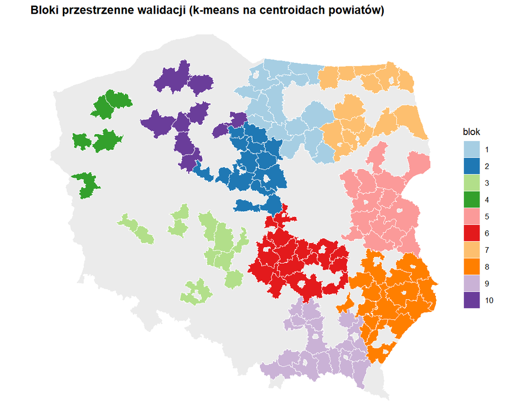

Bloki walidacji

RMSE [‰] w trzech schematach walidacji

| Model | losowy (obserwacje) | przestrzenny blokowy | przestrzenno-czasowy |
| --- | --- | --- | --- |
| Elastic net | 1,921 | 1,937 | 2,123 |
| OLS (pooled) | 1,732 | 1,768 | 2,084 |
| XGBoost | 1,752 | 1,773 | 2,324 |
| poprzedni rok | 2,313 | 2,313 | 2,415 |

## 5. Wymiar przestrzenny (GIS)

**Autokorelacja reszt.** Średni Moran I reszt XGBoost wynosi 0,072 (istotny w 33% lat testowych). Dodanie przestrzennych opóźnień cech (średnia z 8 sąsiadów) daje RMSE 2,296‰ wobec 2,265‰ bez nich. Struktura przestrzenna jest słaba i jawne efekty sąsiedztwa nie poprawiają prognozy.

### Ekonometria przestrzenna: testy LM, SAR, SEM, SARAR, SDM, SDEM

Panelowe modele przestrzenne wymagają ciągłej mapy sąsiedztwa, dlatego estymujemy je na **wszystkich powiatach** (zbalansowany panel 2014–2024). Macierz W to sąsiedztwo graniczne (queen) z granic PRG, standaryzowane wierszami. **Wszystkie modele są wersjami z efektami stałymi powiatu i roku (FE)**, z tą samą specyfikacją co FE: predyktory z t−1, standaryzowane.

Testy mnożnika Lagrange’a dla panelu FE (powiat + rok)

| Test | Statystyka | p |
| --- | --- | --- |
| LM-lag (SAR) | 2,26 | 0.13 |
| LM-error (SEM) | 4,99 | 0.025 |
| odporny LM-lag | 7,78 | 0.0053 |
| odporny LM-error | 10,51 | 0.0012 |

**Wybór modelu.** Testy LM porównują tylko SAR i SEM. Model Durbina (SDM) zawiera oba jako przypadki szczególne (LeSage i Pace 2009), bo dodaje przestrzenne opóźnienia predyktorów WX. Test Walda dla hipotezy, że wszystkie współczynniki przy WX są zerowe: χ² = 64,1, df = 9, p < 0,001. **Hipotezę odrzucamy, więc SDM nie redukuje się do SAR i jest preferowaną specyfikacją.** Charakterystyki sąsiadów (WX) mają znaczenie.

Model SARAR (opóźnienie i błąd przestrzenny jednocześnie) daje przeciwstawne i skrajne oszacowania (ρ = -0,63, λ = 0,58). To typowy objaw słabej identyfikacji przy tej samej macierzy W w obu członach, więc nie interpretujemy go.

Modele z efektami stałymi powiatu i roku; W × = opóźnienie przestrzenne predyktora; *** p<0,01, ** p<0,05, * p<0,1

| Zmienna | FE | SAR | SEM | SARAR | SDM | SDEM |
| --- | --- | --- | --- | --- | --- | --- |
| dochody własne pc | 0,867*** | 0,857*** | 0,845*** | 0,637*** | 0,667*** | 0,674*** |
| udział wydatków inwestycyjnych | 0,043 | 0,043 | 0,042 | 0,021 | 0,027 | 0,026 |
| bezrobocie rejestrowane | 0,413*** | 0,395*** | 0,405*** | 0,582*** | 0,556*** | 0,558*** |
| płace względem kraju | 0,150* | 0,144* | 0,136* | 0,049 | 0,123 | 0,128* |
| firmy / 1000 mieszk. | 1,291*** | 1,296*** | 1,303*** | 1,018*** | 1,118*** | 1,117*** |
| kanalizacja % | 1,182*** | 1,200*** | 1,204*** | 0,729** | 1,039*** | 1,032*** |
| lekarze / 10 tys. | 0,182* | 0,183* | 0,178* | 0,093 | 0,126 | 0,126 |
| udział 65+ | -1,249*** | -1,246*** | -1,280*** | -1,451*** | -1,601*** | -1,592*** |
| gęstość zaludnienia (log) | 3,704*** | 3,666*** | 3,674*** | 3,330*** | 3,294*** | 3,315*** |
| rho_W_y (opóźnienie przestrzenne) |  | 0,028 |  | -0,631*** | 0,033 |  |
| lambda_W_e (błąd przestrzenny) |  |  | 0,045** | 0,584*** |  | 0,034 |
| W × dochody własne pc |  |  |  |  | 0,781*** | 0,815*** |
| W × udział wydatków inwestycyjnych |  |  |  |  | -0,002 | 0,002 |
| W × bezrobocie rejestrowane |  |  |  |  | 0,093 | 0,107 |
| W × płace względem kraju |  |  |  |  | 0,732*** | 0,738*** |
| W × firmy / 1000 mieszk. |  |  |  |  | -0,427 | -0,412 |
| W × kanalizacja % |  |  |  |  | -0,558 | -0,523 |
| W × lekarze / 10 tys. |  |  |  |  | 0,018 | 0,030 |
| W × udział 65+ |  |  |  |  | 1,063*** | 1,029*** |
| W × gęstość zaludnienia (log) |  |  |  |  | 0,489 | 0,575 |

Współczynniki β w SAR i SEM są bardzo zbliżone do FE. W SDM i SDEM, które uwzględniają też **cechy sąsiadów (W ×)**, obraz się uszczegóławia. Współczynniki przy W × są niemal identyczne w SDM i SDEM, więc wnioski o roli sąsiedztwa nie zależą od tego, czy zależność modelujemy przez opóźnienie y, czy przez błąd.

W modelach z opóźnieniem y (SAR, SDM) współczynnik β nie jest efektem krańcowym. Efekt rozkłada się na **bezpośredni** (we własnym powiecie) i **pośredni** (spillover przez sąsiadów, LeSage i Pace 2009):

Efekty w modelu SDM (preferowanym); istotność metodą Monte Carlo (500 losowań). Efekty dla SAR: outputs/przestrzenne_impacts.csv

| Zmienna | Bezpośredni | p | Pośredni (spillover) | p | Całkowity | p |
| --- | --- | --- | --- | --- | --- | --- |
| dochody własne pc | 0,672 | 0,000 | 0,825 | 0,004 | 1,497 | 0,000 |
| udział wydatków inwestycyjnych | 0,027 | 0,532 | -0,001 | 0,984 | 0,026 | 0,780 |
| bezrobocie rejestrowane | 0,557 | 0,000 | 0,115 | 0,532 | 0,671 | 0,004 |
| płace względem kraju | 0,127 | 0,124 | 0,756 | 0,000 | 0,884 | 0,000 |
| firmy / 1000 mieszk. | 1,115 | 0,000 | -0,401 | 0,392 | 0,714 | 0,204 |
| kanalizacja % | 1,036 | 0,000 | -0,538 | 0,268 | 0,498 | 0,464 |
| lekarze / 10 tys. | 0,127 | 0,220 | 0,022 | 0,960 | 0,149 | 0,528 |
| udział 65+ | -1,595 | 0,000 | 1,038 | 0,000 | -0,557 | 0,088 |
| gęstość zaludnienia (log) | 3,298 | 0,000 | 0,616 | 0,680 | 3,914 | 0,020 |

**Starzenie: silny czynnik lokalny, nieistotny w ujęciu regionalnym.** Efekt bezpośredni -1,59 (p < 0,001): wyższy udział 65+ we własnym powiecie oznacza szybszą depopulację. Efekt pośredni ma przeciwny znak, 1,04 (p < 0,001), więc **efekt całkowity wynosi -0,56 (p = 0,088)** i jest statystycznie nieistotny. Starzenie wyraźnie różnicuje powiaty **w obrębie regionu**: starszy powiat traci ludność szybciej niż jego sąsiedzi. Nie wiadomo jednak, czy starzejący się region jako całość traci ludność szybciej. Wynik jest zgodny z przesuwaniem się ludności między sąsiednimi powiatami (młodzi wyjeżdżają z powiatów starszych do pobliskich, młodszych), choć model tego mechanizmu nie dowodzi. To ważne uściślenie względem FE, który pokazuje tylko efekt lokalny.

**Zamożność sąsiedztwa ma znaczenie.** Wyższe dochody własne i płace w **sąsiednich** powiatach wiążą się z wolniejszą depopulacją danego powiatu (W × dochody: 0,78, p = 0,004; W × płace: 0,73, p < 0,001). W efekcie całkowity efekt dochodów (1,50, p < 0,001) i płac (0,88, p < 0,001) jest w dużej części **efektem regionalnym**, a nie lokalnym. Powiat w zamożnym otoczeniu, z dostępem do lepszego rynku pracy w zasięgu dojazdu, traci mniej mieszkańców.

**GW-XGBoost** (XGBoost ważony geograficznie, pasmo wybrane przez walidację leave-location-out):

| k sąsiadów | RMSE CV |
| --- | --- |
| 30 | 2,5323 |
| 60 | 2,3292 |
| 100 | 2,2836 |
| 150 | 2,2671 |
| globalny | 2,2361 |

Średnia lokalna ważność (|SHAP|) jest najwyższa dla: udział 65+, gęstość zaludnienia (log), rok (trend). Odsetek kombinacji powiat × cecha istotnych po korekcie FDR: 0,0%.

Mapa lokalnej ważności cech. Kolor pokazuje **udział cechy w łącznej ważności w danym powiecie** (suma udziałów wszystkich cech = 100%), więc skala jest wspólna dla wszystkich warstw. Cechę wybierasz przełącznikiem po prawej stronie.

[interactive chart not shown]

Starzenie się dominuje niemal wszędzie, dlatego druga mapa pokazuje najważniejszy czynnik **poza udziałem 65+**. To jest profil lokalny, który może ukierunkować interwencję.

[interactive chart not shown]

## 6. Mapa przyszłości: prognoza do 2030

**Model prognozy: elastic net.** W teście odporności (sekcja 4) miał najniższy średni błąd i był istotnie lepszy od FE. Wybraliśmy go jako najprostszy i najstabilniejszy z najlepszych modeli, a nie jako bezwzględnego zwycięzcę (sekcja 4). Był też istotnie lepszy od swojej wersji z progami ALE. To on generuje mapę przyszłości. Hiperparametry (α, λ) dobierane są na ostatnim roku danych uczących, bez mieszania lat. Prognoza jest rekurencyjna: ścieżki predyktorów wyznacza trend z lat 2022–2024, ograniczony do zakresu obserwowanego w danych, a średnia historyczna powiatu jest aktualizowana o kolejne prognozy. Przedział 90% to ±3,42‰ × √horyzont, gdzie q90 pochodzi z błędów elastic net w walidacji kroczącej 2019–2024.

| Rok | Średnia [‰] | Min | Max |
| --- | --- | --- | --- |
| 2025 | -7,79 | -16,17 | 3,04 |
| 2026 | -8,33 | -16,59 | 2,15 |
| 2027 | -8,84 | -17,12 | 1,16 |
| 2028 | -9,36 | -17,53 | 0,49 |
| 2029 | -9,89 | -17,93 | -0,12 |
| 2030 | -10,41 | -18,31 | -0,66 |

Średnio powiaty peryferyjne stracą w latach 2025–2030 **5,3% mieszkańców**.

[interactive chart not shown]

Interaktywna mapa z prognozą dla każdego roku: mapa_interaktywna_prognoz_2025_2030.html

Powiaty o największym prognozowanym ubytku ludności (elastic net)

| # | Powiat | Zmiana 2025–2030 [%] | Prognoza 2030 [‰] |
| --- | --- | --- | --- |
| 1 | powiat hajnowski | -9,9 | -18,31 |
| 2 | powiat hrubieszowski | -9,2 | -17,16 |
| 3 | powiat siemiatycki | -8,5 | -16,29 |
| 4 | powiat sokólski | -8,1 | -15,43 |
| 5 | powiat krasnostawski | -8,1 | -15,31 |
| 6 | powiat kętrzyński | -8,0 | -15,00 |
| 7 | powiat bartoszycki | -7,9 | -14,88 |
| 8 | powiat konecki | -7,8 | -14,73 |
| 9 | powiat tomaszowski | -7,7 | -14,59 |
| 10 | powiat opatowski | -7,7 | -14,68 |
| 11 | powiat lipski | -7,7 | -14,89 |
| 12 | powiat pińczowski | -7,6 | -14,48 |
| 13 | powiat braniewski | -7,6 | -14,07 |
| 14 | powiat parczewski | -7,5 | -14,02 |
| 15 | powiat łobeski | -7,3 | -13,80 |

**Odporność na wybór modelu.** Tę samą prognozę policzyliśmy XGBoostem:

| Model | Średnia zmiana 2025–2030 | Najsilniejszy ubytek | Najniższa prognoza roczna |
| --- | --- | --- | --- |
| Elastic net (główna) | -5,3% | -9,9% | -18,3‰ |
| XGBoost (porównawcza) | -5,1% | -8,5% | -14,9‰ |

Rankingi obu modeli są bardzo zgodne: korelacja Spearmana **0,97**, a 16 z 20 powiatów o największym ryzyku pokrywa się. Różnica dotyczy skali w powiatach najszybciej się wyludniających. XGBoost nie ekstrapoluje poza zakres danych uczących, więc jego prognozy roczne zatrzymują się na -14,9‰. Elastic net, jako model liniowy, tego ograniczenia nie ma, co jest kolejnym argumentem za nim.

## 7. Porównanie typów jednostek: rdzeń, półperyferie, peryferie

Kluczowe kroki powtórzono na **wszystkich 380 powiatach**: trajektorie, FE osobno dla każdej klasy, walidację kroczącą 2019–2024 i prognozę do 2030 z modelu uczonego na pełnym panelu.

[interactive chart not shown]

Peryferie przez cały okres tracą ludność najszybciej: mediana -2,2‰ w 2011 r. wobec -7,5‰ w 2024 r. Rdzeń nie jest jednolity. Należy do niego 126 powiatów, w tym duże miasta na prawach powiatu, które tracą mieszkańców na rzecz rosnących przedmieść (suburbanizacja). Dlatego od 2020 r. mediana rdzenia jest zbliżona do półperyferii.

RMSE [‰] w walidacji kroczącej 2019–2024, model uczony na 380 powiatach

| Klasa | XGBoost | poprzedni rok | FE panelowy | Elastic net |
| --- | --- | --- | --- | --- |
| peryferie | 2,277 | 2,415 | 2,487 | 2,524 |
| półperyferie | 2,086 | 2,170 | 2,309 | 2,242 |
| rdzeń | 2,737 | 2,593 | 2,864 | 2,750 |

Najlepszy model w każdej klasie: peryferie: XGBoost; półperyferie: XGBoost; rdzeń: poprzedni rok. **Na pełnym panelu XGBoost jest lepszy od FE we wszystkich klasach**, choć w samych peryferiach (127 powiatów) nie różnił się od FE istotnie. Modele ML zyskują na większej i bardziej zróżnicowanej próbie. Najtrudniejszy do prognozy jest rdzeń, gdzie miasta i przedmieścia zachowują się odmiennie. Prognozę dla wszystkich powiatów generuje model o najniższym łącznym błędzie na pełnym panelu.

Prognoza zmiany ludności 2025–2030 według klas

| Klasa | Powiaty | Średnia zmiana 2025–2030 | Mediana | Ubytek > 5% | Wzrost ludności |
| --- | --- | --- | --- | --- | --- |
| peryferie | 127 | -5,1% | -5,6% | 66% | 2% |
| półperyferie | 127 | -4,2% | -4,9% | 47% | 5% |
| rdzeń | 126 | -3,5% | -5,0% | 49% | 15% |

[interactive chart not shown]

Panel FE (powiat + rok) osobno dla klas; beta standaryzowane na wspólnej próbie

| Predyktor (t−1) | peryferie | półperyferie | rdzeń |
| --- | --- | --- | --- |
| dochody własne pc | -0,20 | 0,92** | 0,55 |
| udział wydatków inwestycyjnych | 0,27*** | 0,14 | 0,00 |
| bezrobocie rejestrowane | 0,20 | -0,12 | 0,41 |
| płace względem kraju | 0,36 | 0,11 | 0,14** |
| firmy / 1000 mieszk. | 0,10 | 1,56** | 1,18** |
| kanalizacja % | 0,28 | 1,59*** | 1,00 |
| lekarze / 10 tys. | 0,37* | -0,38 | -0,02 |
| udział 65+ | -1,67*** | -0,55 | -1,83*** |
| gęstość zaludnienia (log) | 11,54** | 18,11** | 2,60 |

Starzenie się ludności ma istotny ujemny związek z tempem zmian ludności w peryferiach i w rdzeniu. W półperyferiach silniej zaznaczają się czynniki infrastrukturalne i dochodowe. Gęstość zaludnienia (t−1) w modelu FE pełni głównie rolę zmiennej bezwładności (poziom ludności), dlatego nie należy jej interpretować jako dźwigni polityki.

### Potencjał rozwojowy: typologia trajektorii

Opis projektu pyta nie tylko o depopulację, ale o **ryzyko stagnacji, depopulacji lub potencjał rozwojowy**. Łączymy więc dwa wymiary dla wszystkich powiatów:

- **demograficzny**: prognozowana zmiana ludności 2025–2030 (szybsza lub wolniejsza od mediany kraju),
- **gospodarczy**: trend **relatywnej** pozycji powiatu w latach 2014–2024, czyli średnie nachylenie wskaźników standaryzowanych w każdym roku względem wszystkich powiatów: płace, dochody własne, firmy na 1000 mieszkańców i bezrobocie (ze znakiem minus). Wartość dodatnia oznacza, że powiat dogania resztę kraju.

Wymiar gospodarczy opiera się na obserwowanej trajektorii, a nie na prognozie. Zmienne nominalne (np. dochody) rosną w czasie, a modele drzewiaste nie ekstrapolują trendu, więc ich prognoza sztucznie wskazywałaby stagnację.

[interactive chart not shown]

Liczba powiatów (udział w klasie) według typu trajektorii

| Typ | peryferie | półperyferie | rdzeń |
| --- | --- | --- | --- |
| spirala marginalizacji | 39 (31%) | 22 (17%) | 40 (32%) |
| ryzyko stagnacji | 17 (13%) | 35 (28%) | 40 (32%) |
| kurczenie z poprawą gospodarczą | 37 (29%) | 31 (24%) | 21 (17%) |
| potencjał rozwojowy | 34 (27%) | 39 (31%) | 25 (20%) |

- **Peryferie nie są jednorodne.** 31% z nich jest w **spirali marginalizacji** (szybka depopulacja i relatywne pogorszenie gospodarcze), głównie na wschodzie kraju, ale 27% ma **potencjał rozwojowy**: wolniejszą depopulację i doganianie reszty kraju. Sama klasa „peryferie” nie przesądza o trajektorii.
- Duża grupa peryferii (29%) to **kurczenie z poprawą gospodarczą**: tracą ludność, ale ich wskaźniki per capita się poprawiają. To typowy obraz „kurczenia się z dostosowaniem” (smart shrinking).
- W rdzeniu „spirala” to głównie miasta tracące mieszkańców na rzecz przedmieść.
- Ograniczenie: trend gospodarczy jest relatywny, więc z definicji ok. połowa powiatów ma wartość ujemną. Typologia pokazuje pozycję względną, a nie bezwzględne pogorszenie warunków życia.

## 8. Scenariusze interwencji

Scenariusz **dostępności transportowej** zmniejsza odległość od miasta wojewódzkiego o 20%, co przybliża skrócenie czasu dojazdu (np. nowa droga ekspresowa albo szybsze połączenie kolejowe). Jest to jedyna miara dostępności w danych, więc scenariusz pokazuje kierunek i skalę zjawiska, a nie efekt konkretnej inwestycji.

| Scenariusz | Średni efekt [‰/rok] | Min | Max | Powiaty z poprawą |
| --- | --- | --- | --- | --- |
| pakiet łączny | 0,411 | -0,378 | 1,085 | 94% |
| bezrobocie -2 pp | 0,309 | 0,095 | 0,315 | 100% |
| dostępność: odległość −20% | 0,262 | 0,068 | 0,650 | 100% |
| inwestycje +5 pp | 0,181 | 0,097 | 0,182 | 100% |
| kanalizacja +10 pp | -0,157 | -0,680 | 0,000 | 0% |
| lekarze +20% | -0,185 | -0,361 | 0,044 | 0% |

**Czy te efekty są istotne?** Elastic net nie daje klasycznych p-wartości, bo kara ściąga współczynniki do zera. Dlatego stosujemy **bootstrap blokowy po powiatach**: losujemy powiaty ze zwracaniem (każdy z całą historią), dopasowujemy hybrydę od nowa (razem z doborem α i λ) i liczymy efekt scenariusza na tych samych danych z 2024 r. p-wartość to podwojony odsetek replikacji z efektem o przeciwnym znaku. Wariant główny (1000 replikacji) trzyma progi ALE z pełnej próby. W kontroli (200 replikacji) progi szacujemy od nowa w każdej replikacji, co uwzględnia także niepewność progów.

| Scenariusz | Efekt [‰/rok] | 95% CI | p (progi stałe) | p (progi szacowane) |
| --- | --- | --- | --- | --- |
| bezrobocie -2 pp | 0,31 | [0,17; 0,40] | <0,001 | 0,010 |
| lekarze +20% | -0,18 | [-0,27; -0,03] | 0,002 | 0,010 |
| dostępność: odległość −20% | 0,26 | [0,07; 0,41] | 0,002 | <0,005 |
| firmy +30% | 0,71 | [0,11; 1,39] | 0,016 | 0,050 |
| dochody własne +50% | 2,02 | [0,25; 3,15] | 0,022 | <0,005 |
| pakiet łączny | 0,41 | [0,03; 0,79] | 0,036 | 0,040 |
| inwestycje +5 pp | 0,18 | [-0,00; 0,38] | 0,064 | 0,020 |
| kanalizacja +10 pp | -0,16 | [-0,34; 0,04] | 0,106 | 0,440 |
| pakiet bez dostępności | 0,15 | [-0,20; 0,50] | 0,320 | 0,150 |
| płace +10 pp | -0,06 | [-0,70; 0,47] | 0,678 | 0,990 |

Na poziomie 5% w obu wariantach istotne są: bezrobocie -2 pp, lekarze +20%, dostępność: odległość −20%, dochody własne +50%, pakiet łączny. **Nieistotne** w obu wariantach: kanalizacja +10 pp (p = 0,11), pakiet bez dostępności (p = 0,32), płace +10 pp (p = 0,68). Ich przedziały obejmują zero, więc nie da się nawet rozstrzygnąć znaku efektu. **Na granicy** (istotne tylko w jednym wariancie): firmy +30% (p = 0,016 i 0,050), inwestycje +5 pp (p = 0,064 i 0,020). Ujemny efekt lekarzy jest istotny w obu wariantach (p = 0,002 i 0,01). To prawdopodobnie korelacja, a nie skutek: lepiej wyposażone w lekarzy są większe ośrodki powiatowe, które same tracą mieszkańców. Pakiet łączny jest istotny w obu wariantach (p = 0,036 i 0,040), a pakiet bez dostępności transportowej jest nieistotny (p = 0,32). Pewny kierunek mają więc dźwignie istotne w obu wariantach, a wyniki „na granicy” należy traktować ostrożnie.

### Symulator interwencji (interaktywny)

Przesuń suwaki, a model hybrydowy (elastic net z progami z ALE) przeliczy prognozę rocznej zmiany ludności dla każdego powiatu peryferyjnego. Przeglądarka liczy ją tym samym wzorem co R: wyraz wolny plus suma współczynników razy cechy, z progami i obcięciem cech do zakresu obserwowanego w danych. Zmiana działa tak samo jak w scenariuszach powyżej: trwała zmiana poziomu cechy w latach 2023–2024, a efektem jest różnica prognozy na 2025 r.

Rynek pracy i gospodarka

Usługi i infrastruktura

Średni efekt

0

‰ rocznie

Powiaty z poprawą

0%

efekt > 0,05‰

Mieszkańcy „zatrzymani” rocznie

0

suma w 127 powiatach

Model scenariuszy, 2025 (średnio)

0

‰ (bez interwencji: –)

| Najkorzystniejszy efekt |  |  |
| --- | --- | --- |

| Najmniej korzystny efekt |  |  |
| --- | --- | --- |

[interactive chart not shown]

efekt [‰/rok]:< −1−1 do −0,5−0,5 do −0,2−0,2 do −0,05±0,050,05 do 0,20,2 do 0,50,5 do 1> 1 poza próbą peryferyjną

Symulator pokazuje **zależności predykcyjne** z danych historycznych, a nie skutki przyczynowe. Cechy są obcinane do zakresu obserwowanego w latach 2011–2024, więc duże przesunięcia suwaków „nasycają się”. Suwaki obejmują tylko cechy, na które polityka publiczna ma wpływ. Odległość od miasta wojewódzkiego i udział osób 65+ pozostają stałe, a skrócenie dojazdu jest ocenione osobno w scenariuszu dostępności powyżej. Przycisk „Pakiet usług i rynku pracy” to pakiet łączny z tabeli bez dostępności transportowej. Pod każdym suwakiem widać kierunek tej cechy w modelu i jej istotność z bootstrapu (tabela powyżej). Płace, inwestycje i kanalizacja są nieistotne, więc ich efektu w symulatorze nie należy interpretować. Lekarze mają znak odwrotny niż oczekiwany. Prawdopodobnie lepiej wyposażone są większe ośrodki powiatowe, które same tracą mieszkańców, więc model uczy się korelacji, a nie skutku inwestycji (to nasze przypuszczenie, nie sprawdzaliśmy go osobno). Kafelek „Model scenariuszy, 2025” pokazuje poziom z modelu determinantów (bez historii zmian ludności). Nie jest to główna prognoza z sekcji 6. Symulator służy do porównywania **różnic** między wariantami.

Mapa efektów scenariuszy (model hybrydowy). Przełącznik warstw pozwala wybrać scenariusz.

[interactive chart not shown]

**Kontrola odporności: te same scenariusze w XGBoost i w czystym elastic net.**

Średni efekt [‰/rok] i odsetek powiatów z poprawą > 0,05‰

| Scenariusz | Hybryda [‰/rok] | XGBoost | Elastic net | Poprawa: hybryda | XGB | EN |
| --- | --- | --- | --- | --- | --- | --- |
| pakiet łączny | 0,411 | 0,438 | 0,416 | 94% | 58% | 100% |
| bezrobocie -2 pp | 0,309 | 0,174 | 0,250 | 100% | 63% | 100% |
| dostępność: odległość −20% | 0,262 | 0,257 | 0,263 | 100% | 57% | 97% |
| inwestycje +5 pp | 0,181 | -0,002 | 0,134 | 100% | 25% | 100% |
| kanalizacja +10 pp | -0,157 | 0,116 | -0,167 | 0% | 41% | 1% |
| lekarze +20% | -0,185 | -0,109 | -0,064 | 0% | 29% | 0% |

Żaden model nie daje efektu o przeciwnym znaku niż pozostałe w **5 z 6** scenariuszy (przeciwny znak: kanalizacja +10 pp); w jednym z modeli efekt jest praktycznie zerowy dla: inwestycje +5 pp. Różnią się natomiast **rozkładem efektu dostępności**. Poprawa obejmuje 97% powiatów w czystym elastic net, 100% w hybrydzie i 57% w XGBoost. W modelu głównym (hybrydzie) siła efektu zależy od odległości powiatu od miasta wojewódzkiego:

| Odległość od miasta woj. | Liczba powiatów | Średni efekt [‰/rok] |
| --- | --- | --- |
| do 30 km | 9 | 0,27 |
| 30–51 km (wokół progu) | 39 | 0,45 |
| 51–70 km | 39 | 0,14 |
| ponad 70 km | 40 | 0,20 |

Efekt jest największy w paśmie **30–51 km (wokół progu)**: skrócenie odległości o 20% przesuwa te powiaty poniżej progu ok. 41 km, gdzie odległość silniej różnicuje depopulację. XGBoost skupia efekt jeszcze mocniej (57% powiatów), a czysty elastic net rozkłada go równomiernie. Wszystkie modele zgadzają się, że dostępność pomaga. Modele z progiem wskazują dodatkowo, **gdzie** inwestycja da największy efekt, a to ma znaczenie dla polityki.

**Uwaga interpretacyjna:** to symulacje na modelu predykcyjnym, a nie oszacowania efektów przyczynowych. Model uczy się współwystępowania cech, a nie skutków interwencji. Małe lub ujemne efekty niektórych scenariuszy oznaczają, że w danych historycznych te cechy słabo różnicowały tempo depopulacji przy kontroli struktury wieku. Nie oznaczają, że interwencja szkodzi.

## 10. Ograniczenia

### Elementy opisu projektu, których nie dało się zrealizować na dostępnych danych

[output not shown]

Uzupełnienie tych danych (czas dojazdu z OSRM lub GTFS, UKE, BDL dla usług edukacyjnych) to naturalny kierunek dalszych prac.

### Ograniczenia metodologiczne

- Pełna analiza (GW-XGBoost, scenariusze, diagnostyka przestrzenna) obejmuje 127 powiatów peryferyjnych. Porównanie klas (sekcja 7) ogranicza się do trajektorii, FE, walidacji, prognozy i typologii.
- Modele przestrzenne: istotność efektów bezpośrednich i pośrednich liczona Monte Carlo z niezależnych losowań parametrów (przybliżenie, bo pomija kowariancje oszacowań). Nie wykonano testu czynnika wspólnego SDM vs SEM. Zgodność SDM i SDEM częściowo to rekompensuje. Przy ok. 4000 obserwacjach istotne bywają też małe efekty, więc liczy się także ich wielkość.
- Odległość liczona jest po prostej między centroidami, a nie jako czas dojazdu siecią drogową.
- Brak danych o lekarzach za 2012 r., więc regresja zaczyna się od 2014 r. (analiza wrażliwości z interpolacją: `outputs/analiza_wrazliwosci_lekarze.csv`).
- Prognoza jest rekurencyjna i zakłada kontynuację trendów 2022–2024. Krótkoterminowe przedziały są niedokalibrowane.
- Elastic net jest modelem liniowym. Nieliniowe progi (sekcja 4, ALE) uwzględnia model determinantów XGBoost, ale nie główna prognoza. Prognoza XGBoost, która je uwzględnia, daje bardzo zbliżony ranking, lecz nie ekstrapoluje poza zakres danych (najniższa prognoza roczna -14,9‰).
- Wyniki SHAP, permutation importance i scenariusze opisują model, a nie przyczynowość.

**Zastrzeżenia metodologiczne:**

- Lata testowe 2019–2024 posłużyły też do wyboru modelu, więc jego błąd na tych latach jest lekko optymistyczny (zob. „Czy wybór modelu jest odporny?”, sekcja 4).
- Część decyzji zapadła po obejrzeniu wyników: progi z addytywnego XGBoost, rezygnacja z interakcji, rzadsza siatka α. Każda ma uzasadnienie i jest opisana, ale łącznie zwiększają ryzyko dopasowania analizy do danych.
- Scenariusze pokazują zależności z danych, a nie skutki przyczynowe (np. ujemny „efekt” lekarzy).
- Prognoza do 2030 r. zakłada, że cechy zmieniają się zgodnie z trendem z lat 2022–2024 i pozostają w zakresie danych. Nie uwzględnia nowych wstrząsów (migracyjnych, gospodarczych).

## 11. Reprodukcja

Kod i dane: https://github.com/Dawid27G/depopulacja-peryferii-gis-ml. W folderze repozytorium:

```
Rscript analiza_peryferyjnosc.R
Rscript -e "rmarkdown::render('RAPORT_ANALIZA_PERYFERYJNOSC.Rmd')"
```

Pełny przebieg skryptu trwa ok. 50 minut (random search XGBoost, bootstrap, GW-XGBoost). Wersje pakietów R są w pliku `PAKIETY_R.txt`.